# FBMS: Flexible Bayesian Model Selection and Model Averaging

This vignette introduces the **FBMS** package and shows how to perform **Flexible Bayesian Model Selection (BMS)** and **Bayesian Model Averaging (BMA)** for linear, generalized, nonlinear, fractional–polynomial, mixed–effect, and logic–regression models. More details are provided in the paper: “FBMS: An R Package for Flexible Bayesian Model Selection and Model Averaging” available on arxiv: more explicit examples accompanying the paper can be found on github https://github.com/jonlachmann/GMJMCMC/tree/data-inputs/tests_current

# Setup

Load technical markdown settings and a custom function for printing only what is needed through **`printn()`**.

# Bayesian Model Selection and Averaging

1. Consider a class of models: $\Omega: m_1(Y|X,\theta_1), \dots, m_k(Y|X,\theta_k)$.
2. Assign priors to models $P(m_1), \dots, P(m_k)$ and parameters $P(\theta_j|m_j)$.
3. Obtain joint posterior $P(m_j,\theta_j|D)$.
4. Make inference on a quantity of interest $\Delta$.

**Show equations**

$$P(\Delta|D) = \sum_{m\in\Omega} P(m|D)\, \int_{\Theta_m}
P(\Delta|m,\theta,D)\, P(\theta|m,D)\, d\theta.$$

## Bayesian Generalized Nonlinear Model (BGNLM)

**Reference**: [@hubin2020flexible]

**Show equations**

$$\begin{aligned}
Y_i \mid \mu_i, \phi &\sim \mathfrak{f}(y \mid \mu_i,\phi), \quad i
= 1,\dots,n,\\
\mathsf{h}(\mu_i) &= \beta_0 + \sum_{j=1}^{q} \gamma_j \beta_j
F_j(\mathbf{x}_i, \boldsymbol{\alpha}_j) + \sum_{k=1}^{r} \delta_k.
\end{aligned}$$

- **Predictors (features)**: $F_j(\mathbf{x}_i, \boldsymbol{\alpha}_j)$, $j=1,\dots,q$
- **Random effects**: $\delta_k$
- **Total models**: $2^{q+r}$

### Feature space

Depending on allowed nonlinear functions $\mathbb{G}$: neural nets (sigmoid), decision trees (thresholds), MARS (hinges), fractional polynomials, logic regression, etc.

### Transformations available in `FBMS`

| Name | Function | Name | Function |
| --- | --- | --- | --- |
| sigmoid | $1 / (1 + \exp(-x))$ | sqroot | $\|x\|^{1/2}$ |
| relu | $\max(x, 0)$ | troot | $\|x\|^{1/3}$ |
| nrelu | $\max(-x, 0)$ | sin_deg | $\sin(x/180 \cdot \pi)$ |
| hs | $x > 0$ | cos_deg | $\cos(x/180 \cdot \pi)$ |
| nhs | $x < 0$ | exp_dbl | $\exp(-\|x\|)$ |
| gelu | $x \Phi(x)$ | gauss | $\exp(-x^2)$ |
| ngelu | $-x \Phi(-x)$ | erf | $2 \Phi(\sqrt{2}x) - 1$ |
| pm2 | $x^{-2}$ | p0pm2 | $p0(x) \cdot x^{-2}$ |
| pm1 | $\text{sign}(x) \|x\|^{-1}$ | p0pm05 | $p0(x) \cdot \|x\|^{-0.5}$ |
| pm05 | $\|x\|^{-0.5}$ | p0p0 | $p0(x)^2$ |
| p05 | $\|x\|^{0.5}$ | p0p05 | $p0(x) \cdot \|x\|^{0.5}$ |
| p2 | $x^2$ | p0p1 | $p0(x) \cdot x$ |
| p3 | $x^3$ | p0p2 | $p0(x) \cdot x^2$ |
|  |  | p0p3 | $p0(x) \cdot x^3$ |

*Custom functions can be added to* $\mathbb{G}$.

## Priors

### Model priors

Let $M = (\gamma_1, \dots, \gamma_q)$ (for linear models $q=p$).

**Penalizing complexity priors**

**Show equation**

$$P(M) \propto \mathbb{I}(|\boldsymbol\gamma_{1:q}| \le Q)
\prod_{j=1}^q r^{\gamma_j c(F_j(\mathbf{x},
\boldsymbol{\alpha}_j))}, \quad 0 < r < 1,$$

- $c(F_j(\cdot))$: complexity measure (linear models: $c(x)=1$; BGNLM counts algebraic operators).

The following parameter will be used to change the prior penalization.

```r
# model prior complexity penalty
model_prior = list(r = 0.005) #default is 1/n
```

### Parameter priors

**Mixtures of g-priors**

**Show equations**

$$\begin{aligned}
P(\beta_0, \phi \mid M) &\propto \phi^{-1}, \\
P(\boldsymbol{\beta} \mid g) &\sim
\mathbb{N}_{|M|}\!\left(\mathbf{0},\, g \cdot \phi\,
J_n(\boldsymbol{\beta})^{-1}\right), \\
\frac{1}{1+g} &\sim \text{tCCH}\!\left(\frac{a}{2}, \frac{b}{2},
\rho, \frac{s}{2}, v, \kappa\right).
\end{aligned}$$

- **Robust-g** (convenient default): $a=1, b=2, \rho=1.5, s=0, v=\frac{n+1}{|M|+1}, \kappa=1$.

**Jeffreys prior**

**Show equations**

$$P(\phi \mid M) = \phi^{-1}, \quad
P(\beta_0, \boldsymbol{\beta} \mid M) = |J_n(\beta_0,
\boldsymbol{\beta})|^{1/2}.$$

**All priors from the table below (default is the g-prior)**

### Parameter priors available (and where to tune)

| Prior (Alias) | $a$ | $b$ | $\rho$ | $s$ | $v$ | $k$ | Families |
| --- | --- | --- | --- | --- | --- | --- | --- |
| **Default:** |  |  |  |  |  |  |  |
| `g-prior` | $g$ (default: $\max(n, p^2)$) |  |  |  |  |  | GLM |
| **tCCH-Related Priors:** |  |  |  |  |  |  |  |
| `CH` | $a$ | $b$ | 0 | $s$ | 1 | 1 | GLM |
| `uniform` | 2 | 2 | 0 | 0 | 1 | 1 | GLM |
| `Jeffreys` | 0 | 2 | 0 | 0 | 1 | 1 | GLM |
| `beta.prime` | $1/2$ | $n - p_M - 1.5$ | 0 | 0 | 1 | 1 | GLM |
| `benchmark` | 0.02 | $0.02 \max(n, p^2)$ | 0 | 0 | 1 | 1 | GLM |
| `TG` | $2a$ | 2 | 0 | $2s$ | 1 | 1 | GLM |
| `ZS-adapted` | 1 | 2 | 0 | $n + 3$ | 1 | 1 | GLM |
| `robust` | 1 | 2 | 1.5 | 0 | $(n+1)/(p_M+1)$ | 1 | GLM |
| `hyper-g-n` | 1 | 2 | 1.5 | 0 | 1 | $1/n$ | GLM |
| `intrinsic` | 1 | 1 | 1 | 0 | $(n + p_M + 1)/(p_M + 1)$ | $(n + p_M + 1)/n$ | GLM |
| `tCCH` | $a$ | $b$ | $\rho$ | $s$ | $v$ | $k$ | GLM |
| **Other Priors:** |  |  |  |  |  |  |  |
| `EB-local` | $a$ |  |  |  |  |  | GLM |
| `EB-global` | $a$ |  |  |  |  |  | G |
| `JZS` | $a$ |  |  |  |  |  | G |
| `ZS-null` | $a$ |  |  |  |  |  | G |
| `ZS-full` | $a$ |  |  |  |  |  | G |
| `hyper-g` | $a$ |  |  |  |  |  | GLM |
| `hyper-g-laplace` | $a$ |  |  |  |  |  | G |
| `AIC` | None |  |  |  |  |  | GLM |
| `BIC` | None |  |  |  |  |  | GLM |
| `Jeffreys-BIC` | Var |  |  |  |  |  | GLM |

*Here* $p_M$ is the number of predictors excluding the intercept. “G” denotes Gaussian-only; “GLM” additionally includes binomial, Poisson, and gamma.

**How to switch priors in code (be explicit):**

```r
# g-prior with g = 1000
beta_prior = list(type = "g-prior", alpha = 1000)

# Robust prior (tune by Table parameters)
beta_prior = list(type = "robust")

# Jeffreys-BIC
beta_prior = list(type = "Jeffreys-BIC")

# Generic tCCH (provide all hyperparameters explicitly)
beta_prior = list(type = "tCCH", a = 2, b = 2, rho = 0, s = 0, v = 1, k = 1)
```

# Inference algorithms

### Model posterior

**Show equations**

**Marginal likelihood**
$$P(D|M) = \int_{\Theta_M} P(D|\theta_M, M) \, P(\theta_M|M) \, d\theta_M.$$

**Posterior**
$$P(M|D) = \frac{P(D|M) P(M)}{\sum_{M' \in \Omega} P(D|M')
P(M')}.$$

**Approximation over discovered models** $\Omega^*$
$$P(M|D) \approx \frac{P(D|M) P(M)}{\sum_{M' \in \Omega^*} P(D|M')
P(M')}, \quad M \in \Omega^*.$$

**Marginal inclusion probability**
$$P(\gamma_j=1|D) \approx \sum_{M \in \Omega^*: \gamma_j=1} P(M|D).$$

### MCMC, MJMCMC, GMJMCMC

- Variable selection spans exponential number of models; naive MCMC can get trapped.
- **MJMCMC**: random mode jumps + local improvements; valid MH acceptance [@hubin2018mode].
- **GMJMCMC**: embeds MJMCMC in a genetic algorithm to traverse huge spaces [@hubin2020logic; @hubin2020flexible].
- **RGMJMCMC**: reversible version [@hubin2021reversible].
- **Subsampling**: efficient for tall data [@lachmann2022subsampling].

### Parallelization

Run multiple chains and aggregate unique models $\Omega^*$:

**Show equation**

$$\widehat{P}(\Delta|D) = \sum_{M \in \Omega^*} P(\Delta|M,D) \,
\widehat{P}(M|D).$$

```r
# Parameters for parallel runs are set to a single thread and single core to comply with CRAN requirenments (please tune for your machine if you have more capacity)
runs  <- 1  # 1 set for simplicity; use rather 16 or more
cores <- 1  # 1 set for simplicity; use rather 8 or more
```

# Example 1 — BGNLM: recovering Kepler’s third law

**Data**: $n=939$ exoplanets; variables include `semimajoraxis`, `period`, `hoststar_mass`, etc.  
Target relationship: ${a \approx K_2 \left(P^2 M_h\right)^{1/3}}$.

We shall run a single chain **GMJMCMC**

```r
# Load example
data <- FBMS::exoplanet

# Choose a small but expressive transform set for a quick demo
transforms <- c("sigmoid", "sin_deg", "exp_dbl", "p0", "troot", "p3")

# ---- fbms() call (simple GMJMCMC) ----
# Key parameters (explicit):
# - formula      : semimajoraxis ~ 1 + .       # response and all predictors
# - data         : data                        # dataset
# - beta_prior   : list(type = "g-prior")      # parameter prior
# - model_prior  : list(r = 1/dim(data)[1])    # model prior
# - method       : "gmjmcmc"                   # exploration strategy
# - transforms   : transforms                  # nonlinear feature dictionary
# - P            : population size per generation (search breadth)
result_single <- fbms(
  formula     = semimajoraxis ~ 1 + .,
  data        = data,
  beta_prior  = list(type = "g-prior", alpha = dim(data)[1]),
  model_prior = list(r = 1/dim(data)[1]),
  method      = "gmjmcmc",
  transforms  = transforms,
  P           = 10
)

# Summarize
printn(summary(result_single))
```

```
##
## Best   population: 8  log marginal posterior: 3047.559
##
##                                     feats.strings   marg.probs
## 1                                          period 1.0000000000
## 2 ((period*hoststar_mass)*(period*hoststar_mass)) 1.0000000000
## 3                                   troot(period) 1.0000000000
## 4                          (period*hoststar_mass) 1.0000000000
## 5                          (period*troot(period)) 1.0000000000
## 6                               p0(troot(period)) 1.0000000000
## 7                                      p3(period) 0.9999999999
## 8                             p3(hoststar_radius) 0.0001441497
```

**and a parallel GMJMCMC**

```r
# ---- fbms() call (parallel GMJMCMC) ----
# Key parameters (explicit):
# - formula      : semimajoraxis ~ 1 + .       # response and all predictors
# - data         : data                        # dataset
# - beta_prior   : list(type = "g-prior")      # parameter prior
# - model_prior  : list(r = 1/dim(data)[1])    # model prior
# - method       : "gmjmcmc"                   # exploration strategy
# - transforms   : transforms                  # nonlinear feature dictionary
# - runs, cores  : parallelization controls
# - P            : population size per generation (search breadth)
result_parallel <- fbms(
  formula     = semimajoraxis ~ 1 + .,
  data        = data,
  beta_prior  = list(type = "g-prior", alpha = dim(data)[1]),
  model_prior = list(r = 1/dim(data)[1]),
  method      = "gmjmcmc.parallel",
  transforms  = transforms,
  runs        = runs,     # by default the rmd has runs =  1; increase for convergence
  cores       = cores,    # by default the rmd has cores = 1; increase for convergence
  P           = 10
)

# Summarize
printn(summary(result_parallel))
```

```
##
## Best   population: 10  thread: 1  log marginal posterior: 3051.56
##
##                             feats.strings marg.probs
## 1                troot(1+1*troot(period))  1.0000000
## 2         (sigmoid(hoststar_mass)*period)  1.0000000
## 3  (troot(period)*sigmoid(hoststar_mass))  1.0000000
## 4 ((period*sigmoid(eccentricity))*period)  1.0000000
## 5                           troot(period)  1.0000000
## 6                       p0(troot(period))  1.0000000
## 7                  sigmoid(hoststar_mass)  0.9999998
## 8                                  period  0.9999453
```

**Plot output**

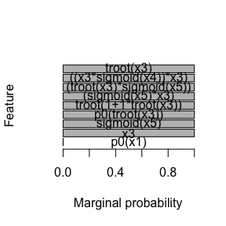

```r
plot(result_parallel)
```

**Convergence plots**

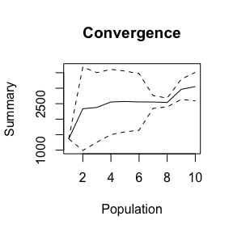

```r
diagn_plot(result_parallel)
```

# Example 2 — Bayesian linear models

**Reference**: [@hubin2018mode]

**Model**

$$\begin{aligned}
Y_i \mid \mu_i, \phi &\sim \mathfrak{f}(y\mid \mu_i, \phi), \quad
i=1,\dots,n, \\
\mathsf{h}(\mu_i) &= \beta_0 + \sum_{j=1}^{p} \gamma_j \beta_j
x_{ij}.
\end{aligned}$$

We simulate data with a known sparse truth and run **MJMCMC** with an explicit **g-prior**.

```r
library(mvtnorm)

n <- 100               # sample size
p <- 20                # number of covariates
k <- 5                 # size of true submodel

correct.model <- 1:k
beta.k <- (1:5)/5

beta <- rep(0, p)
beta[correct.model] <- beta.k

set.seed(123)
x <- rmvnorm(n, rep(0, p))
y <- x %*% beta + rnorm(n)

# Standardize
y <- scale(y)
X <- scale(x) / sqrt(n)

df <- as.data.frame(cbind(y, X))
colnames(df) <- c("Y", paste0("X", seq_len(ncol(df) - 1)))

printn(correct.model)
```

```
## [1] 1 2 3 4 5
```

```r
printn(beta.k)
```

```
## [1] 0.2 0.4 0.6 0.8 1.0
```

**Run MJMCMC with a g-prior (g = 100)**

```r
# ---- fbms() call (MJMCMC) ----
# Explicit prior choice:
#   beta_prior = list(type = "g-prior", alpha = 100)
# To switch to another prior, e.g. robust:
#   beta_prior = list(type = "robust")
result.lin <- fbms(
  formula    = Y ~ 1 + .,
  data       = df,
  method     = "mjmcmc",
  N          = 5000,                         # number of iterations
  beta_prior = list(type = "g-prior", alpha = 100)
)
```

**Plot results**

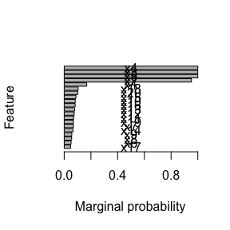

```r
plot(result.lin)
```

**Summarize with posterior effects**

```r
# 'effects' specifies quantiles for posterior modes of effects across models
printn(summary(result.lin, effects = c(0.5, 0.025, 0.975)))
```

```
##
## Best log marginal posterior:  56.2259
##
## $PIP
##    feats.strings marg.probs
## 1             X4 1.00000000
## 2             X3 1.00000000
## 3             X5 1.00000000
## 4             X2 0.95262397
## 5             X1 0.16880319
## 6            X18 0.10464730
## 7            X20 0.10105529
## 8            X15 0.08767336
## 9            X10 0.08257391
## 10           X16 0.08200567
```

[output cut: 34 more lines]

**Run parallel MJMCMC**

```r
# ---- fbms() call (parallel MJMCMC) ----
# Explicit prior choice:
#   beta_prior = list(type = "g-prior", alpha = 100)
# To switch to another prior, e.g. robust:
#   beta_prior = list(type = "robust")
#   method = mjmcmc.parallel
#   runs, cores  : parallelization controls
result.lin.par <- fbms(
  formula    = Y ~ 1 + .,
  data       = df,
  method     = "mjmcmc.parallel",
  N          = 5000,                         # number of iterations
  beta_prior = list(type = "g-prior", alpha = 100),
  runs = runs,
  cores = cores
)
printn(summary(result.lin.par, effects = c(0.5, 0.025, 0.975)))
```

```
##
## Best log marginal posterior:  56.2259
##
## $PIP
##    feats.strings marg.probs
## 1             X4 1.00000000
## 2             X3 1.00000000
## 3             X5 1.00000000
## 4             X2 0.95518016
## 5             X1 0.17518018
## 6            X10 0.10751407
## 7            X20 0.10044924
## 8            X18 0.09363710
## 9            X16 0.09089584
## 10           X15 0.08729800
```

[output cut: 34 more lines]

# Example 3 — Bayesian Fractional Polynomials (FP)

**Reference**: [@hubin2023fractional]

We augment the linear example to follow an FP truth and fit with **GMJMCMC**.

**FP model class**

$$\begin{aligned}
Y_i \mid \mu_i, \phi &\sim \mathfrak{f}(y|\mu_i,\phi),\\
\mathsf{h}(\mu_i) &= \beta_0 + \sum_{j=1}^{p} \sum_{k \in K}
\gamma_{jk}\, \beta_{jk}\, \rho_k(x_{ij}), \quad \text{with } K =
\mathbf{F}_0 \cup \mathbf{F}_1 \cup \mathbf{F}_2,
\end{aligned}$$

```r
# Create FP-style response with known structure, covariates are from previous example
df$Y <- p05(df$X1) + df$X1 + pm05(df$X3) + p0pm05(df$X3) + df$X4 +
         pm1(df$X5) + p0(df$X6) + df$X8 + df$X10 + rnorm(nrow(df))

# Allow common FP transforms
transforms <- c(
  "p0", "p2", "p3", "p05", "pm05", "pm1", "pm2", "p0p0",
  "p0p05", "p0p1", "p0p2", "p0p3", "p0p05", "p0pm05", "p0pm1", "p0pm2"
)

# Generation probabilities — here only modifications and mutations
probs <- gen.probs.gmjmcmc(transforms)
probs$gen <- c(0, 1, 0, 1)

# Feature-generation parameters
params <- gen.params.gmjmcmc(ncol(df) - 1)
params$feat$D <- 1   # max depth 1 features
```

**Run GMJMCMC (single-thread)**

```r
result <- fbms(
  formula    = Y ~ 1 + .,
  data       = df,
  method     = "gmjmcmc",
  transforms = transforms,
  beta_prior = list(type = "Jeffreys-BIC"),
  probs      = probs,
  params     = params,
  P          = 10
)

printn(summary(result))
```

```
##
## Best   population: 10  log marginal posterior: -206.4266
##
##    feats.strings   marg.probs
## 1       pm05(X3) 1.0000000000
## 2       p0p0(X3) 1.0000000000
## 3        pm1(X5) 1.0000000000
## 4     p0pm05(X6) 0.9999959549
## 5      p0pm1(X3) 0.9359835862
## 6            X17 0.8981659238
## 7            X15 0.8795347468
## 8            X10 0.8584612830
## 9             X9 0.8507841966
## 10    p0pm2(X13) 0.7855348631
## 11           X20 0.1825368449
## 12            X4 0.0362927730
## 13            X7 0.0166240434
## 14           X13 0.0079441065
## 15            X2 0.0002276410
## 16     p0p3(X20) 0.0001784105
```

**Parallel GMJMCMC**

```r
result_parallel <- fbms(
  formula    = Y ~ 1 + .,
  data       = df,
  method     = "gmjmcmc.parallel",
  transforms = transforms,
  beta_prior = list(type = "Jeffreys-BIC"),
  probs      = probs,
  params     = params,
  P          = 10,
  runs       = runs,
  cores      = cores
)

printn(summary(result_parallel))
```

```
##
## Best   population: 10  thread: 1  log marginal posterior: -506.0695
##
##   feats.strings  marg.probs
## 1    p0pm05(X3) 1.000000000
## 2            X5 1.000000000
## 3       pm2(X5) 1.000000000
## 4            X3 0.398001125
## 5      p0p0(X3) 0.001258547
```

# Example 4 — Mixed-effects FP with interactions

Dataset: $n=659$ kids; response $y$: standardized height; covariates: `c.bf, c.age, m.ht, m.bmi, reg`. Random intercept for `dr.`  
We specify a **custom estimator** that uses a mixed model (via `lme4`), and plug it into `fbms()` with `family = "custom"`. We pass extra parameters of the estimator through `mlpost_params = list(dr = dr,r = r)`

```r
# Custom approximate log marginal likelihood for mixed model using Laplace approximation
mixed.model.loglik.lme4 <- function (y, x, model, complex, mlpost_params) {
  if (sum(model) > 1) {
    x.model <- x[, model]
    data <- data.frame(y, x = x.model[, -1], dr = mlpost_params$dr)
    mm <- lmer(as.formula(paste0("y ~ 1 +",
                          paste0(names(data)[2:(ncol(data)-1)], collapse = "+"),
                          " + (1 | dr)")), data = data, REML = FALSE)
  } else {
    data <- data.frame(y, dr = mlpost_params$dr)
    mm <- lmer(y ~ 1 + (1 | dr), data = data, REML = FALSE)
  }
  # log marginal likelihood (Laplace approx) + log model prior
  mloglik <- as.numeric(logLik(mm)) - 0.5 * log(length(y)) * (ncol(data) - 2)
  if (length(mlpost_params$r) == 0) mlpost_params$r <- 1 / nrow(x)
  lp <- log_prior(mlpost_params, complex)
  list(crit = mloglik + lp, coefs = fixef(mm))
}
```

```r
library(lme4)
data(Zambia, package = "cAIC4")

df <- as.data.frame(sapply(Zambia[1:5], scale))

transforms <- c("p0","p2","p3","p05","pm05","pm1","pm2",
                "p0p0","p0p05","p0p1","p0p2","p0p3",
                "p0p05","p0pm05","p0pm1","p0pm2")

probs <- gen.probs.gmjmcmc(transforms)
probs$gen <- c(1, 1, 0, 1) # include modifications and interactions

params <- gen.params.gmjmcmc(ncol(df) - 1)
params$feat$D <- 1
params$feat$pop.max <- 10

result2a <- fbms(
  formula      = z ~ 1 + .,
  data         = df,
  method       = "gmjmcmc.parallel",
  transforms   = transforms,
  probs        = probs,
  params       = params,
  P            = 10,
  N            = 100,
  runs         = runs,
  cores        = cores,
  family       = "custom",
  loglik.pi    = mixed.model.loglik.lme4,
  model_prior  = list(r = 1 / nrow(df)), # model_prior is passed to mlpost_params
  extra_params = list(dr = droplevels(Zambia$dr)) # extra_params are passed to mlpost_params
)

printn(summary(result2a, tol = 0.05, labels = names(df)[-1]))
```

```
##
## Best   population: 6  thread: 1  log marginal posterior: -876.5476
##
##   feats.strings marg.probs
## 1          c.bf  1.0000000
## 2         c.age  1.0000000
## 3         m.bmi  1.0000000
## 4          m.ht  1.0000000
## 5 (c.age*c.age)  0.9999999
```

# Example 5 — Bayesian Logic Regression

**Reference**: [@hubin2020logic]

**Model**

$$\mathsf{h}(\mu_i) = \beta_0 + \sum_{j=1}^{q} \gamma_j \beta_j L_{ji},
\quad
L_{ji} \text{ are logic trees (e.g., } (x_{i1}\wedge x_{i2}) \vee
x_{i3}^c ).$$

We generate Boolean covariates and a known logic signal, define a custom estimator with a **logic prior**, and fit via **GMJMCMC**.

```r
n <- 2000
p <- 50

set.seed(1)
X2 <- as.data.frame(matrix(rbinom(n * p, size = 1, prob = runif(n * p, 0, 1)), n, p))
y2.Mean <- 1 + 7*(X2$V4*X2$V17*X2$V30*X2$V10) + 9*(X2$V7*X2$V20*X2$V12) +
           3.5*(X2$V9*X2$V2) + 1.5*(X2$V37)

Y2 <- rnorm(n, mean = y2.Mean, sd = 1)
df <- data.frame(Y2, X2)

# Train/test split
df.training <- df[1:(n/2), ]
df.test     <- df[(n/2 + 1):n, ]
df.test$Mean <- y2.Mean[(n/2 + 1):n]
```

**Custom estimator with logic regression priors**

```r
estimate.logic.lm <- function(y, x, model, complex, mlpost_params) {
  suppressWarnings({
    mod <- fastglm(as.matrix(x[, model]), y, family = gaussian())
  })
  mloglik <- -(mod$aic + (log(length(y)) - 2) * (mod$rank)) / 2
  wj <- complex$width
  lp <- sum(log(factorial(wj))) - sum(wj * log(4 * mlpost_params$p) - log(4))
  logpost <- mloglik + lp
  if (logpost == -Inf) logpost <- -10000
  list(crit = logpost, coefs = mod$coefficients)
}
```

**Run GMJMCMC**

```r
set.seed(5001)

# Only "not" operator; "or" is implied by De Morgan via "and" + "not"
transforms <- c("not")
probs <- gen.probs.gmjmcmc(transforms)
probs$gen <- c(1, 1, 0, 1) # no projections

params <- gen.params.gmjmcmc(p)
params$feat$pop.max <- 50
params$feat$L <- 15

result <- fbms(
  formula     = Y2 ~ 1 + .,
  data        = df.training,
  method      = "gmjmcmc",
  transforms  = transforms,
  N           = 500,
  P           = 10,
  family      = "custom",
  loglik.pi   = estimate.logic.lm,
  probs       = probs,
  params      = params,
  model_prior = list(p = p)
)

printn(summary(result))
```

```
##
## Best   population: 9  log marginal posterior: -1912.786
##
##           feats.strings   marg.probs
## 1        ((V4*V10)*V17) 1.0000000000
## 2               (V9*V2) 1.0000000000
## 3                   V37 1.0000000000
## 4        ((V20*V7)*V12) 1.0000000000
## 5  (V33*(V30*(V4*V17))) 0.9999999179
## 6                   V30 0.9999969055
## 7                   V17 0.0137256351
## 8                   V32 0.0025183771
## 9                   V35 0.0020386609
## 10                  V12 0.0013621295
## 11                  V45 0.0012730261
## 12                  V18 0.0012697929
## 13                  V16 0.0010825818
## 14                  V41 0.0010734783
## 15                  V44 0.0009967761
## 16                  V31 0.0009461623
## 17                   V8 0.0008938150
## 18                  V13 0.0007713390
## 19                   V3 0.0006926010
## 20                  V24 0.0006547320
## 21                  V21 0.0006439233
## 22                  V49 0.0006393027
## 23                   V9 0.0006283463
## 24                  V36 0.0006209956
## 25                  V15 0.0006131099
```

```r
# Extract models
mpm   <- get.mpm.model(result, y = df.training$Y2, x = df.training[,-1],
                       family = "custom", loglik.pi = estimate.logic.lm, params = list(p = 50))
printn(mpm$coefs)
```

```
##          (Intercept)       ((V4*V10)*V17)              (V9*V2)
##            0.6578016            2.7049544            3.5767605
##                  V30                  V37 (V33*(V30*(V4*V17)))
##            0.6051133            1.3582049            2.1279042
##       ((V20*V7)*V12)
##            9.1213744
```

```r
mpm2  <- get.mpm.model(result, y = df.training$Y2, x = df.training[,-1])
printn(mpm2$coefs)
```

```
##          (Intercept)       ((V4*V10)*V17)              (V9*V2)
##            0.6578016            2.7049544            3.5767605
##                  V30                  V37 (V33*(V30*(V4*V17)))
##            0.6051133            1.3582049            2.1279042
##       ((V20*V7)*V12)
##            9.1213744
```

```r
mbest <- get.best.model(result)
printn(mbest$coefs)
```

```
##            Intercept       ((V4*V10)*V17)              (V9*V2)
##            0.6578016            2.7049544            3.5767605
##                  V30                  V37 (V33*(V30*(V4*V17)))
##            0.6051133            1.3582049            2.1279042
##       ((V20*V7)*V12)
##            9.1213744
```

**Prediction**

```r
# Correct link is identity for Gaussian
pred       <- predict(result, x = df.test[,-1], link = function(x) x)
pred_mpm   <- predict(mpm,   x = df.test[,-1], link = function(x) x)
pred_best  <- predict(mbest, x = df.test[,-1], link = function(x) x)

# RMSEs
printn(sqrt(mean((pred$aggr$mean - df.test$Y2)^2)))
```

```
## [1] 1.528321
```

```r
printn(sqrt(mean((pred_mpm     - df.test$Y2)^2)))
```

```
## [1] 1.528355
```

```r
printn(sqrt(mean((pred_best    - df.test$Y2)^2)))
```

```
## [1] 1.528355
```

```r
printn(sqrt(mean((df.test$Mean - df.test$Y2)^2)))
```

```
## [1] 1.028222
```

```r
# Errors to the true mean (oracle)
printn(sqrt(mean((pred$aggr$mean - df.test$Mean)^2)))
```

```
## [1] 1.076062
```

```r
printn(sqrt(mean((pred_best      - df.test$Mean)^2)))
```

```
## [1] 1.076113
```

```r
printn(sqrt(mean((pred_mpm       - df.test$Mean)^2)))
```

```
## [1] 1.076113
```

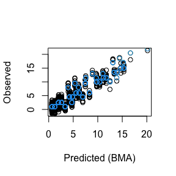

```r
# Quick diagnostic plot
plot(pred$aggr$mean, df.test$Y2,
     xlab = "Predicted (BMA)", ylab = "Observed")
points(pred$aggr$mean, df.test$Mean, col = 2)
points(pred_best,      df.test$Mean, col = 3)
points(pred_mpm,       df.test$Mean, col = 4)
```

# Example 6 — Full BGNLM classification (Bernoulli): `spam` data

We fit a binomial BGNLM and compare BMA, best-model, and MPM predictions.  
**Important:** specify the correct link in `predict()` (here logistic).

```r
library(kernlab)
data("spam")

df <- spam[, c(58, 1:57)]
n  <- nrow(df)
p  <- ncol(df) - 1

colnames(df) <- c("y", paste0("x", 1:p))
df$y <- as.numeric(df$y == "spam")

to3 <- function(x) x^3
transforms <- c("sigmoid","sin_deg","exp_dbl","p0","troot","to3")
probs <- gen.probs.gmjmcmc(transforms)
probs$gen <- c(1, 1, 1, 1)

params <- gen.params.gmjmcmc(p)
params$feat$check.col <- FALSE

set.seed(6001)
result <- fbms(
  formula    = y ~ 1 + .,
  data       = df,
  method     = "gmjmcmc",
  family     = "binomial",
  beta_prior = list(type = "Jeffreys-BIC"),
  transforms = transforms,
  probs      = probs,
  params     = params
)

printn(summary(result))
```

```
##
## Best   population: 2  log marginal posterior: -1009.773
##
##             feats.strings   marg.probs
## 1                     x20 1.0000000000
## 2                      x5 1.0000000000
## 3                      x6 1.0000000000
## 4                      x8 1.0000000000
## 5                     x55 1.0000000000
## 6            sigmoid(x21) 1.0000000000
## 7                     x16 1.0000000000
## 8                     x21 1.0000000000
## 9                     x23 1.0000000000
## 10                    x24 1.0000000000
## 11                    x27 1.0000000000
```

[output cut: 29 more lines]

**Prediction accuracy**

```r
# Logistic link
invlogit <- function(x) 1/(1 + exp(-x))

# Model averaging
pred <- predict(result, x = df[,-1], link = invlogit)
printn(mean(round(pred$aggr$mean) == df$y))
```

```
## [1] 0.9402304
```

```r
# Best model
bm <- get.best.model(result)
preds <- predict(bm, df[,-1], link = invlogit)
printn(mean(round(preds) == df$y))
```

```
## [1] 0.9402304
```

```r
# Median Probability Model
mpm <- get.mpm.model(result, family = "binomial", y = df$y, x = df[,-1])
preds_mpm <- predict(mpm, df[,-1], link = invlogit)
printn(mean(round(preds_mpm) == df$y))
```

```
## [1] 0.9402304
```

# References

- Hubin, A., Storvik, G. (2018). *Mode jumping MCMC for Bayesian variable selection in GLMs.*
- Hubin, A., Frommlet, F., & Storvik, G. (2020). *Flexible Bayesian Model Averaging for Generalized Nonlinear Models.*
- Hubin, A., et al. (2020). *Bayesian Logic Regression via GMJMCMC.*
- Hubin, A., et al. (2021). *Reversible GMJMCMC.*
- Lachmann, J., et al. (2022). *Subsampling for tall data in GMJMCMC.*